# Day 1 Part 3: Random Walks

Author

Dr Christian Engels

Last updated

November 16, 2024

## Load Libraries

Load necessary libraries for data manipulation, finance data, and time-series analysis. These libraries will enable us to generate, visualize, and analyze random walks, which are fundamental to understanding stochastic processes in time series econometrics.

```r
library(tidyverse)
library(tidyfinance)
library(tsibble)
library(fable)
library(feasts)
library(scales)
library(fixest)
```

## Illustrating a Random Walk

Generate and visualize a single random walk. A random walk is a simple but important stochastic process used in time series analysis to model variables whose changes are entirely unpredictable. Here, we simulate a single random walk to understand its behavior.

Mathematically, a random walk can be represented as:

$$y_t = y_{t-1} + e_t$$

where $e_t$ is white noise, typically assumed to be normally distributed with mean zero and constant variance. The difference between consecutive values, $y_t - y_{t-1} = e_t$, is white noise, which implies that the changes in a random walk are completely random and unpredictable.

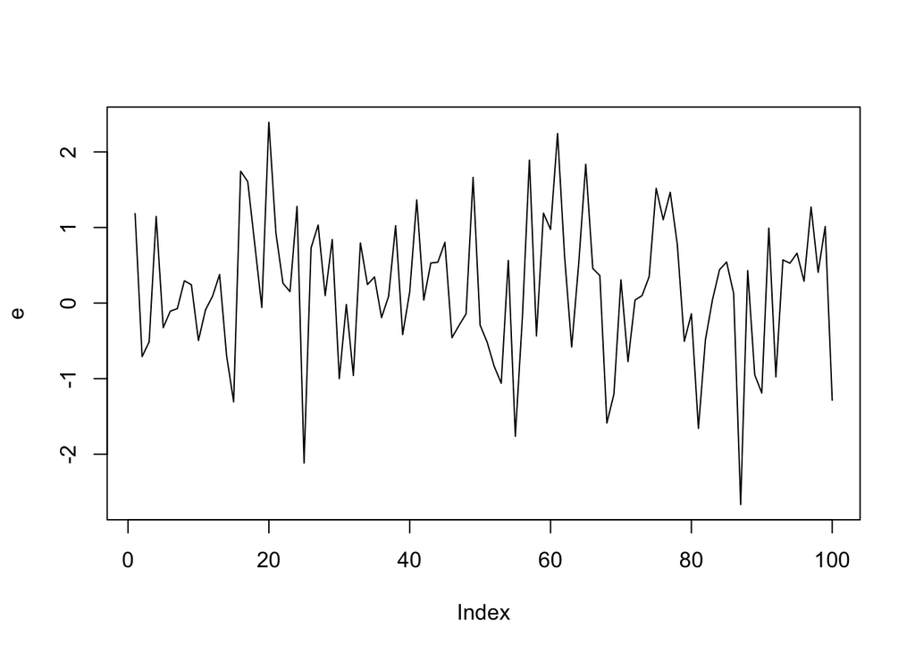

```r
steps <- 100
e <- rnorm(steps)
y <- e
coef <- 1
drift = 0

plot(e, type="l")
```

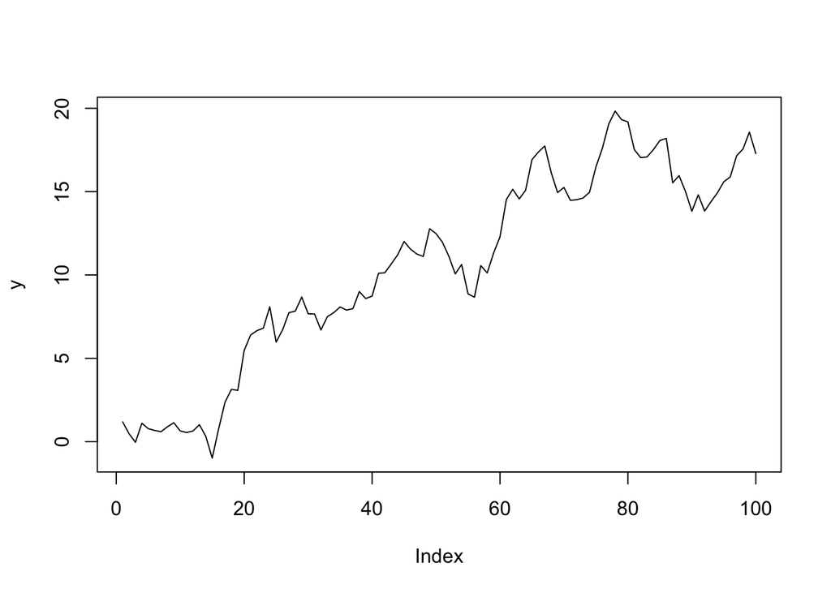

```r
for (i in 2:steps) {
  y[i] <- drift + coef*y[i-1] + e[i]
}

plot(y, type="l")
```

## Multiple Random Walks

Generate and visualize multiple random walks. Generating multiple random walks allows us to explore the variability between different realizations of the process, illustrating the concept of stochasticity and highlighting the random nature of these paths.

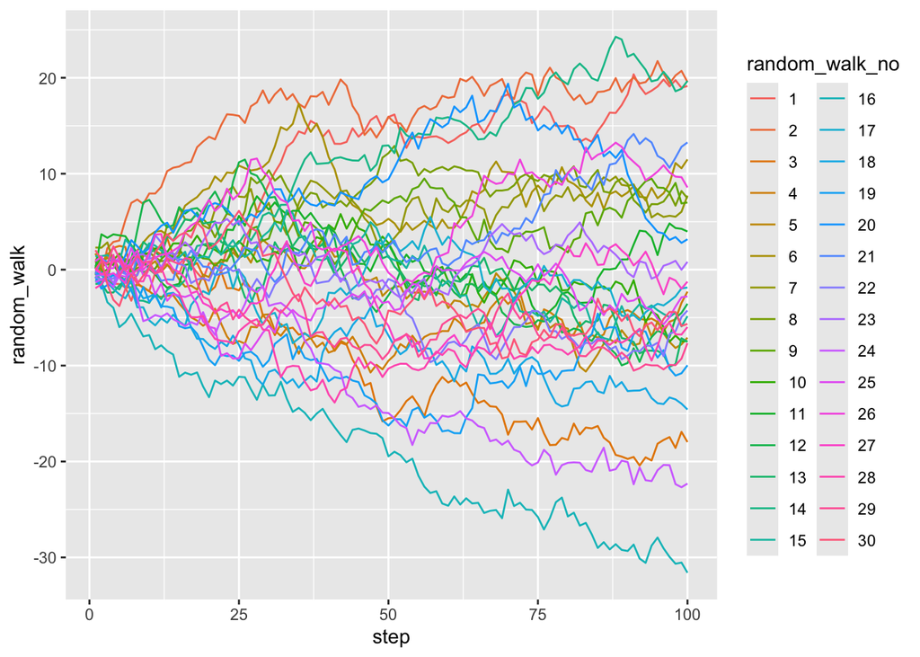

```r
n_random_walks <- 30

create_random_walk <-
  function(random_walk_no, steps = 100, n_random_walks = 30) {

    innovations <-
      tibble(
        random_walk_no,
        step = 1:steps,
        e = rnorm(steps)
      )

    random_walk <-
      innovations %>%
        mutate(
          random_walk = cumsum(e),
          random_walk_no = factor(random_walk_no, 1:n_random_walks)
        )

    return(random_walk)
  }

random_walks <-
  1:n_random_walks %>%
    map(~create_random_walk(.)) %>%
    list_rbind()

random_walks %>%
  ggplot(aes(x = step, y = random_walk, color = random_walk_no)) +
  geom_line()
```

## Analysis of a Single Random Walk

Analyze a single random walk with a lag variable. Here, we analyze the properties of a single random walk by estimating a regression with a lagged variable. This helps us understand if past values of the walk can predict future values, which is key to determining whether the series is truly a random walk.

```r
random_walk_1 <-
  random_walks %>%
  filter(random_walk_no == 1) %>%
  mutate(random_walk_lag = lag(random_walk)) %>%
  remove_missing() %>%
  print()
```

```
# A tibble: 99 × 5
   random_walk_no  step       e random_walk random_walk_lag
   <fct>          <int>   <dbl>       <dbl>           <dbl>
 1 1                  2  0.313        0.298         -0.0152
 2 1                  3 -1.32        -1.03           0.298
 3 1                  4 -0.428       -1.45          -1.03
 4 1                  5 -0.0534      -1.51          -1.45
 5 1                  6 -0.332       -1.84          -1.51
 6 1                  7 -1.40        -3.24          -1.84
 7 1                  8  1.89        -1.35          -3.24
 8 1                  9 -0.575       -1.92          -1.35
 9 1                 10 -0.327       -2.25          -1.92
10 1                 11  1.92        -0.333         -2.25
# ℹ 89 more rows
```

Next, we estimate the following regression equation:

$$y_t = \beta y_{t-1} + \epsilon_t$$

where $y_t$ is the value of the random walk at time $t$, $y_{t-1}$ is the lagged value at time $t-1$, $\beta$ is the estimated coefficient, and $\epsilon_t$ is the residual (error term). In this case, there is no intercept term, which is why the regression formula includes $-1$ to remove the intercept.

```r
est <- feols(random_walk ~ random_walk_lag - 1, data = random_walk_1)
etable(est)
```

```
                              est
Dependent Var.:       random_walk

random_walk_lag 1.008*** (0.0077)
_______________ _________________
S.E. type                     IID
Observations                   99
R2                        0.98021
Adj. R2                   0.98021
---
Signif. codes: 0 '***' 0.001 '**' 0.01 '*' 0.05 '.' 0.1 ' ' 1
```

## Monte Carlo Simulation of Random Walks

```r
random_walks <-
  1:10^3 %>%
  map(~create_random_walk(.)) %>%
  list_rbind() %>%
  group_by(random_walk_no) %>%
  mutate(random_walk_lag = lag(random_walk)) %>%
  remove_missing() %>%
  nest() %>%
  mutate(
    est = map(data, ~feols(random_walk ~ random_walk_lag - 1, data = .)),
    coef = map(est, ~.$coefficients)
  ) %>%
  unnest(cols = coef) %>%
  ungroup()
random_walks
```

[output not shown]

## Summary of Coefficients

Summarize and visualize the distribution of estimated coefficients. Summarizing the coefficients from the Monte Carlo simulations allows us to visualize the typical behavior of the estimated relationships in random walks, such as their average and variability. This can help us draw conclusions about the nature of randomness and persistence in these series.

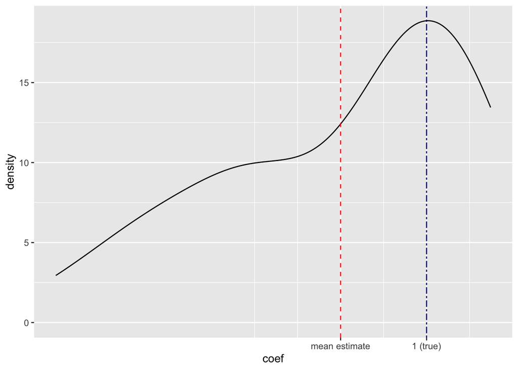

```r
coef_mean <- random_walks %>% summarise(coef_mean = mean(coef)) %>% pull(coef_mean)

random_walks %>%
  ggplot(aes(coef)) +
  geom_density() +
  geom_vline(xintercept = coef_mean, linetype = "dashed", color = "red") +
  geom_vline(xintercept = 1, linetype = "twodash", color = "navy") +
  scale_x_continuous(
    breaks = c(coef_mean, 1),
    labels = c("coef_mean" = "mean estimate", "1" = "1 (true)")
  )
```